# Reproducible Research

Biostat 203B

Dr. Hua Zhou @ UCLA

Jan 14, 2020

## Reproducible research in statistics/data science

> An article about computational science in a scientific publication is **not** the scholarship itself, it is merely **advertising** of the scholarship. The actual scholarship is the complete software development environment and the complete set of instructions which generated the figures.

> Buckheit and Donoho (1995)

## Non-reproducible research

### [Duke Potti scandal](https://en.wikipedia.org/wiki/Anil_Potti)

[figure not shown]

- Potti et al. (2006): https://www.nature.com/articles/nm1491
- Baggerly and Coombes (2009): https://projecteuclid.org/euclid.aoas/1267453942
- [Simply Statistics Blog: The Duke Saga Starter Set](https://simplystatistics.org/2012/02/27/the-duke-saga-starter-set/)

### Microarray studies

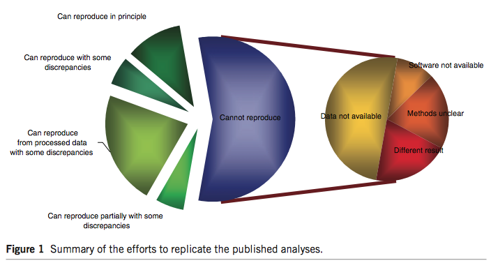

Nature Genetics (2015 Impact Factor: 31.616). 20 articles about microarray profiling published in Nature Genetics between Jan 2005 and Dec 2006.

### Bible code

[figure not shown]

[figure not shown]

[figure not shown]

- Witztum, Rips, and Rosenberg (1994)
- McKay et al. (1999)

## Why reproducible research

- Reproducibility has been the foundation of science. It helps accumulate scientific knowledge.
- Greater research impact.
- Better work habit boosts quality of research.
- Better teamwork. For **you** as graduate students, it means better communication with your advisor.

  ```r
  while true
    Student: "that idea you told me to try - it doesn't work!"
    Professor: "ok. how about trying this instead."
  end
  ```

  Unless you reproduce the computing environment (algorithms, dataset, tuning parameters), others cannot help you.

## How to be reproducible in data science?

> When we publish articles containing figures which were generated by computer, we also publish the complete software environment which generates the figures.

> Buckheit and Donoho (1995)
- A good example: http://stanford.edu/~boyd/papers/admm_distr_stats.html
- I **highly** recommend the book *Reproducible Research with R and RStudio* by Christopher Gandrud.
  - [Amazon](https://www.amazon.com/Reproducible-Research-Studio-Chapman-Hall/dp/1466572841)
  - [GitHub repo](https://github.com/christophergandrud/Rep-Res-Book)

## Tools for reproducible research

- Version control: Git+GitHub.
- Distribute method implementation, e.g., R/Python/Julia packages, on GitHub or bitbucket.
- Dynamic document: RMarkdown for R or [Jupyter](http://jupyter.org) for Julia/Python/R.
- Docker container for reproducing a computing environment.
- Cloud computing tools.
- We are going to practice reproducible research **now**. That is to make your homework reproducible using Git, GitHub, and RMarkdown.

## References

Baggerly, Keith A., and Kevin R. Coombes. 2009. “Deriving Chemosensitivity from Cell Lines: Forensic Bioinformatics and Reproducible Research in High-Throughput Biology.” *Ann. Appl. Stat.* 3 (4). The Institute of Mathematical Statistics: 1309–34. https://doi.org/10.1214/09-AOAS291.

Buckheit, JonathanB., and DavidL. Donoho. 1995. “WaveLab and Reproducible Research.” In *Wavelets and Statistics*, edited by Anestis Antoniadis and Georges Oppenheim, 103:55–81. Lecture Notes in Statistics. Springer New York. https://doi.org/10.1007/978-1-4612-2544-7_5.

McKay, Brendan, Dror Bar-Natan, Maya Bar-Hillel, and Gil Kalai. 1999. “Solving the Bible Code Puzzle.” *Statist. Sci.* 14 (2). The Institute of Mathematical Statistics: 150–73. https://doi.org/10.1214/ss/1009212243.

Potti, Anil, Holly K. Dressman, Andrea Bild, and Richard F. Riedel. 2006. “Genomic signatures to guide the use of chemotherapeutics.” *Nature Medicine* 12 (11). [1] Center for Applied Genomics; Technology, Duke Institute for Genome Sciences; Policy, Duke University, Box 3382, Durham, North Carolina 27710, USA. [2] Department of Medicine, Duke University Medical Center, Box 31295, Durham, North Carolina 27710, USA.: Nature Publishing Group: 1294–1300. https://doi.org/10.1038/nm1491.

Witztum, Doron, Eliyahu Rips, and Yoav Rosenberg. 1994. “Equidistant Letter Sequences in the Book of Genesis.” *Statist. Sci.* 9 (3). The Institute of Mathematical Statistics: 429–38. https://doi.org/10.1214/ss/1177010393.